# finalprojectcode

**调用包**

```python
import pandas as pd
import matplotlib.pyplot as plt
import seaborn as sns
import numpy as np
import math as math
import numpy.linalg as nlg
from scipy.stats import bartlett
from plotnine import *
from scipy.stats import norm
from sklearn.preprocessing import StandardScaler
from factor_analyzer import FactorAnalyzer, calculate_kmo, calculate_bartlett_sphericity
from scipy import stats
import statsmodels.api as sm
import statsmodels.formula.api as smf
import statsmodels.graphics.api as smg
import warnings
warnings.filterwarnings('ignore')
%matplotlib inline
# 内嵌绘图 可以省略掉plt.show这一步
```

**定义示性变量类**

```python
#定义一个示性变量类  将输入的Series转换为多个示性变量 并输出为df
class Characteristic:
    def __init__(self,X,ty):
        self.__data = X
        self.__variables = [x for x in set(self.__data)]
        self.__count=len(set(self.__data))
        self.__type=ty

    def getvariables(self):
        return self.__variables

    def getcount(self):
        return self.__count

    def trans(self):
        arr = []
        for ty in self.__variables[:-1]:
            temp = []
            for va in self.__data:
                if va==ty:temp.append(1)
                else:temp.append(0)
            arr.append(temp)
        df = pd.DataFrame(arr)
        df=df.T
        df.columns=[str(x)+"("+self.__type+")" for x in self.__variables[:-1]]
        return df
```

# 读取数据

数据来源：kaggle  
https://www.kaggle.com/c/house-prices-advanced-regression-techniques/data

```python
df_train = pd.read_csv("train.csv")
```

```python
df_train.head()
```

|  | Id | MSSubClass | MSZoning | LotFrontage | LotArea | Street | Alley | LotShape | LandContour | Utilities | ... | PoolArea | PoolQC | Fence | MiscFeature | MiscVal | MoSold | YrSold | SaleType | SaleCondition | SalePrice |
| --- | --- | --- | --- | --- | --- | --- | --- | --- | --- | --- | --- | --- | --- | --- | --- | --- | --- | --- | --- | --- | --- |
| 0 | 1 | 60 | RL | 65.0 | 8450 | Pave | NaN | Reg | Lvl | AllPub | ... | 0 | NaN | NaN | NaN | 0 | 2 | 2008 | WD | Normal | 208500 |
| 1 | 2 | 20 | RL | 80.0 | 9600 | Pave | NaN | Reg | Lvl | AllPub | ... | 0 | NaN | NaN | NaN | 0 | 5 | 2007 | WD | Normal | 181500 |
| 2 | 3 | 60 | RL | 68.0 | 11250 | Pave | NaN | IR1 | Lvl | AllPub | ... | 0 | NaN | NaN | NaN | 0 | 9 | 2008 | WD | Normal | 223500 |
| 3 | 4 | 70 | RL | 60.0 | 9550 | Pave | NaN | IR1 | Lvl | AllPub | ... | 0 | NaN | NaN | NaN | 0 | 2 | 2006 | WD | Abnorml | 140000 |
| 4 | 5 | 60 | RL | 84.0 | 14260 | Pave | NaN | IR1 | Lvl | AllPub | ... | 0 | NaN | NaN | NaN | 0 | 12 | 2008 | WD | Normal | 250000 |

5 rows × 81 columns

```python
Id = df_train.pop('Id')
#df_train = df_train.set_index(Id)
```

```python
df_train.shape
```

```
(1460, 80)
```

# 数据预处理

**相关性**

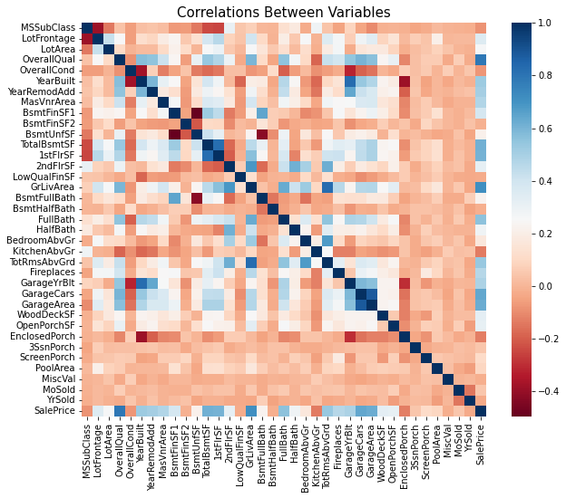

```python
plt.figure(figsize=(10,8))
sns.heatmap(df_train.corr(),cmap='RdBu')
plt.title('Correlations Between Variables',size=15)
```

存在相关性，可继续进行分析

**查看缺失值**

```python
#missing data
total = df_train.isnull().sum().sort_values(ascending=False)
percent = (df_train.isnull().sum()/df_train.isnull().count()).sort_values(ascending=False)
missing_data = pd.concat([total, percent], axis=1, keys=['Total', 'Percent'])
missing_data.head(20)
```

|  | Total | Percent |
| --- | --- | --- |
| PoolQC | 1453 | 0.995205 |
| MiscFeature | 1406 | 0.963014 |
| Alley | 1369 | 0.937671 |
| Fence | 1179 | 0.807534 |
| FireplaceQu | 690 | 0.472603 |
| LotFrontage | 259 | 0.177397 |
| GarageYrBlt | 81 | 0.055479 |
| GarageCond | 81 | 0.055479 |
| GarageType | 81 | 0.055479 |
| GarageFinish | 81 | 0.055479 |
| GarageQual | 81 | 0.055479 |
| BsmtExposure | 38 | 0.026027 |
| BsmtFinType2 | 38 | 0.026027 |
| BsmtCond | 37 | 0.025342 |
| BsmtQual | 37 | 0.025342 |
| BsmtFinType1 | 37 | 0.025342 |
| MasVnrArea | 8 | 0.005479 |
| MasVnrType | 8 | 0.005479 |
| Electrical | 1 | 0.000685 |
| MSSubClass | 0 | 0.000000 |

由data_decription.txt中可知，一些变量中的NA并非缺失值，而是调查问卷中所存在的选项，故对数据先进行一部分处理后再处理缺失值

**对有序变量编码**

Alley

```python
df_train['Alley'] = df_train['Alley'].replace(['NA','Pave','Grvl'],[0,1,2])
```

LotShape

```python
df_train['LotShape'] = df_train['LotShape'].replace(['Reg','IR1','IR2','IR3'],[0,1,2,3])
```

LandContour

```python
df_train['LandContour'] = df_train['LandContour'].replace(['Lv1','Low','HLS','Bnk'],[0,1,2,3])
```

LandSlope

```python
df_train['LandSlope'] = df_train['LandSlope'].replace(['Gtl','Mod','Sev'],[0,1,2])
```

ExterQual

```python
df_train['ExterQual'] = df_train['ExterQual'].replace(['Ex','Gd','TA','Fa','Po'],[4,3,2,1,0])
```

BsmtQual

```python
df_train['BsmtQual'] = df_train['BsmtQual'].replace(['NA','Po', 'Fa', 'TA', 'Gd', 'Ex'],[0,1,2,3,4,5])
```

BsmtCond

```python
df_train['BsmtCond'] = df_train['BsmtCond'].replace(['NA','Po', 'Fa', 'TA', 'Gd', 'Ex'],[0,1,2,3,4,5])
```

BsmtExposure

```python
df_train['BsmtExposure'] = df_train['BsmtExposure'].replace(['NA','No','Mn','Av','Gd'],[0,1,2,3,4])
```

BsmtFinType1

```python
df_train['BsmtFinType1'] = df_train['BsmtFinType1'].replace(['NA','Unf','Lwq','Rec','BLQ','ALQ','GLQ'],[0,1,2,3,4,5,6])
```

BsmtFinType2

```python
df_train['BsmtFinType2'] = df_train['BsmtFinType2'].replace(['NA','Unf','Lwq','Rec','BLQ','ALQ','GLQ'],[0,1,2,3,4,5,6])
```

HeatingQC

```python
df_train['HeatingQC'] = df_train['HeatingQC'].replace(['Po', 'Fa', 'TA', 'Gd', 'Ex'],[0,1,2,3,4])
```

CentralAir

```python
df_train['CentralAir'] = df_train['CentralAir'].replace(['N','Y'],[0,1])
```

KitchenQual

```python
df_train['KitchenQual'] = df_train['KitchenQual'].replace(['Po', 'Fa', 'TA', 'Gd', 'Ex'],[0,1,2,3,4])
```

FireplaceQu

```python
df_train['FireplaceQu'] = df_train['FireplaceQu'].replace(['NA','Po', 'Fa', 'TA', 'Gd', 'Ex'],[0,1,2,3,4,5])
```

PavedDrive

```python
df_train['PavedDrive'] = df_train['PavedDrive'].replace(['N','P','Y'],[0,1,2])
```

PoolQC

```python
df_train['PoolQC'] = df_train['PoolQC'].replace(['NA', 'Fa', 'TA', 'Gd', 'Ex'],[0,1,2,3,4])
```

Fence

```python
df_train['Fence'] = df_train['Fence'].replace(['NA', 'MnWw', 'GdWo', 'MnPrv', 'GdPrv'],[0,1,2,3,4])
```

**对分类变量进行处理**

GarageType

```python
setgt=['2Types', 'Attchd', 'Basment', 'BuiltIn', 'CarPort', 'Detchd']
arr=[]
for ty in setgt:
    temp = []
    for va in df_train['GarageType']:
        if va==ty:temp.append(1)
        else:temp.append(0)
    arr.append(temp)
df=pd.DataFrame(arr).T
df.columns=[str(x)+"(GarageType)" for x in setgt]
df_train=df_train.drop('GarageType',axis=1)
df_train=pd.concat([df_train,df],axis=1)
```

Heating

```python
setht=['Floor', 'GasA', 'GasW', 'Grav', 'Wall']
arr=[]
for ty in setht:
    temp = []
    for va in df_train['Heating']:
        if va==ty:temp.append(1)
        else:temp.append(0)
    arr.append(temp)
df=pd.DataFrame(arr).T
df.columns=[str(x)+"(Heating)" for x in setht]
df_train=df_train.drop('Heating',axis=1)
df_train=pd.concat([df_train,df],axis=1)
```

Electrical

```python
setet=['FuseA', 'FuseF', 'FuseP', 'Mix', 'SBrkr']
arr=[]
for ty in setet:
    temp = []
    for va in df_train['Electrical']:
        if va==ty:temp.append(1)
        else:temp.append(0)
    arr.append(temp)
df=pd.DataFrame(arr).T
df.columns=[str(x)+"(Electrical)" for x in setet]
df_train=df_train.drop('Electrical',axis=1)
df_train=pd.concat([df_train,df],axis=1)
```

GarageFinish

```python
setgf=['Fin', 'RFn', 'Unf']
arr=[]
for ty in setgf:
    temp = []
    for va in df_train['GarageFinish']:
        if va==ty:temp.append(1)
        else:temp.append(0)
    arr.append(temp)
df=pd.DataFrame(arr).T
df.columns=[str(x)+"(GarageFinish)" for x in setgf]
df_train=df_train.drop('GarageFinish',axis=1)
df_train=pd.concat([df_train,df],axis=1)
```

MiscFeature

```python
setmf=['Gar2', 'Othr', 'Shed', 'TenC']
arr=[]
for ty in setmf:
    temp = []
    for va in df_train['MiscFeature']:
        if va==ty:temp.append(1)
        else:temp.append(0)
    arr.append(temp)
df=pd.DataFrame(arr).T
df.columns=[str(x)+"(MiscFeature)" for x in setmf]
df_train=df_train.drop('MiscFeature',axis=1)
df_train=pd.concat([df_train,df],axis=1)
```

SaleType

```python
setst=['COD', 'CWD', 'Con', 'ConLD', 'ConLI', 'ConLw', 'New', 'WD']
arr=[]
for ty in setst:
    temp = []
    for va in df_train['SaleType']:
        if va==ty:temp.append(1)
        else:temp.append(0)
    arr.append(temp)
df=pd.DataFrame(arr).T
df.columns=[str(x)+"(SaleType)" for x in setst]
df_train=df_train.drop('SaleType',axis=1)
df_train=pd.concat([df_train,df],axis=1)
```

**缺失值处理**

```python
#missing data
total = df_train.isnull().sum().sort_values(ascending=False)
percent = (df_train.isnull().sum()/df_train.isnull().count()).sort_values(ascending=False)
missing_data = pd.concat([total, percent], axis=1, keys=['Total', 'Percent'])
missing_data.head(20)
```

|  | Total | Percent |
| --- | --- | --- |
| PoolQC | 1453 | 0.995205 |
| Alley | 1369 | 0.937671 |
| Fence | 1179 | 0.807534 |
| FireplaceQu | 690 | 0.472603 |
| LotFrontage | 259 | 0.177397 |
| GarageCond | 81 | 0.055479 |
| GarageQual | 81 | 0.055479 |
| GarageYrBlt | 81 | 0.055479 |
| BsmtFinType2 | 38 | 0.026027 |
| BsmtExposure | 38 | 0.026027 |
| BsmtFinType1 | 37 | 0.025342 |
| BsmtCond | 37 | 0.025342 |
| BsmtQual | 37 | 0.025342 |
| MasVnrType | 8 | 0.005479 |
| MasVnrArea | 8 | 0.005479 |
| Attchd(GarageType) | 0 | 0.000000 |
| 2Types(GarageType) | 0 | 0.000000 |
| SalePrice | 0 | 0.000000 |
| SaleCondition | 0 | 0.000000 |
| YrSold | 0 | 0.000000 |

由于变量'PoolQC', 'Alley', 'Fence', 'FireplaceQu', 'LotFrontage'的缺失值过多，直接将这几个变量剔除。 变量'GarageYrBlt', 'GarageCond', 'GarageQual'的缺失值数量相同，且其都为对车库状态的描述，因此猜测可能来自相同样本的缺失，不便进行缺失值补充，因此选择剔除这几个变量。 BsmtFinType2,BsmtExposure,BsmtQual,BsmtCond,BsmtFinType1，对于这几个变量，和MasVnrArea，MasVnrType，我们也予以同样的考量，予以剔除。

```python
#dealing with missing data
df_train = df_train.drop((missing_data[missing_data['Total'] > 1]).index,1)
df_train.isnull().sum().max() #再次进行检验是否存在缺失值
#删除存在缺失值的变量
```

```
0
```

**其余需要修改为示性变量的分类变量**

```python
colstr=[]
for i in range(62):
    if type(df_train.iloc[0,i])==str:colstr.append(i)
#查找需要改为示性变量的列索引
#返回相应的列名
col=df_train.iloc[:,colstr].columns.values
```

```python
for x in col:
    X=Characteristic(df_train[x],x)
    df_train=pd.concat([df_train,X.trans()],axis=1)
```

```python
df_train=df_train.drop(col,axis=1)
```

```python
df_train = df_train.set_index(Id)
SalePrice=df_train["SalePrice"]
df_train=df_train.drop('SalePrice',axis=1)
df_train.insert(195,'SalePrice',SalePrice)
```

```python
df_train.shape
```

```
(1460, 196)
```

```python
df_train.head()
```

| Id | MSSubClass | LotArea | LotShape | LandSlope | OverallQual | OverallCond | YearBuilt | YearRemodAdd | ExterQual | BsmtFinSF1 | ... | Maj2(Functional) | Maj1(Functional) | Min1(Functional) | Sev(Functional) | AdjLand(SaleCondition) | Partial(SaleCondition) | Alloca(SaleCondition) | Family(SaleCondition) | Normal(SaleCondition) | SalePrice |
| --- | --- | --- | --- | --- | --- | --- | --- | --- | --- | --- | --- | --- | --- | --- | --- | --- | --- | --- | --- | --- | --- |
| 1 | 60 | 8450 | 0 | 0 | 7 | 5 | 2003 | 2003 | 3 | 706 | ... | 0 | 0 | 0 | 0 | 0 | 0 | 0 | 0 | 1 | 208500 |
| 2 | 20 | 9600 | 0 | 0 | 6 | 8 | 1976 | 1976 | 2 | 978 | ... | 0 | 0 | 0 | 0 | 0 | 0 | 0 | 0 | 1 | 181500 |
| 3 | 60 | 11250 | 1 | 0 | 7 | 5 | 2001 | 2002 | 3 | 486 | ... | 0 | 0 | 0 | 0 | 0 | 0 | 0 | 0 | 1 | 223500 |
| 4 | 70 | 9550 | 1 | 0 | 7 | 5 | 1915 | 1970 | 2 | 216 | ... | 0 | 0 | 0 | 0 | 0 | 0 | 0 | 0 | 0 | 140000 |
| 5 | 60 | 14260 | 1 | 0 | 8 | 5 | 2000 | 2000 | 3 | 655 | ... | 0 | 0 | 0 | 0 | 0 | 0 | 0 | 0 | 1 | 250000 |

5 rows × 196 columns

**探索性回归分析**

```python
ols_train = sm.OLS(df_train['SalePrice'],df_train.iloc[:,:-1]).fit()
ols_train.summary()
```

OLS Regression Results

| Dep. Variable: | SalePrice | R-squared (uncentered): | 0.986 |
| --- | --- | --- | --- |
| Model: | OLS | Adj. R-squared (uncentered): | 0.984 |
| Method: | Least Squares | F-statistic: | 469.2 |
| Date: | Thu, 06 Jan 2022 | Prob (F-statistic): | 0.00 |
| Time: | 14:35:33 | Log-Likelihood: | -16757. |
| No. Observations: | 1460 | AIC: | 3.390e+04 |
| Df Residuals: | 1269 | BIC: | 3.491e+04 |
| Df Model: | 191 |  |  |
| Covariance Type: | nonrobust |  |  |

|  | coef | std err | t | P>\|t\| | [0.025 | 0.975] |
| --- | --- | --- | --- | --- | --- | --- |
| MSSubClass | -65.6079 | 88.236 | -0.744 | 0.457 | -238.712 | 107.496 |
| LotArea | 0.5189 | 0.096 | 5.390 | 0.000 | 0.330 | 0.708 |
| LotShape | 257.4666 | 1467.457 | 0.175 | 0.861 | -2621.442 | 3136.375 |
| LandSlope | 3438.7113 | 3705.588 | 0.928 | 0.354 | -3831.042 | 1.07e+04 |
| OverallQual | 8905.5039 | 1069.896 | 8.324 | 0.000 | 6806.544 | 1.1e+04 |
| OverallCond | 5161.9512 | 912.059 | 5.660 | 0.000 | 3372.643 | 6951.260 |
| YearBuilt | 281.1407 | 76.895 | 3.656 | 0.000 | 130.285 | 431.996 |
| YearRemodAdd | 13.5548 | 57.888 | 0.234 | 0.815 | -100.012 | 127.122 |
| ExterQual | 5530.2114 | 2246.341 | 2.462 | 0.014 | 1123.261 | 9937.162 |
| BsmtFinSF1 | 19.8724 | 2.159 | 9.204 | 0.000 | 15.637 | 24.108 |
| BsmtFinSF2 | 5.8058 | 3.610 | 1.608 | 0.108 | -1.277 | 12.888 |
| BsmtUnfSF | -3.9463 | 2.084 | -1.893 | 0.059 | -8.035 | 0.143 |
| TotalBsmtSF | 21.7318 | 3.297 | 6.591 | 0.000 | 15.263 | 28.201 |
| HeatingQC | 1082.7386 | 1035.115 | 1.046 | 0.296 | -947.987 | 3113.464 |
| CentralAir | -3421.5660 | 4142.939 | -0.826 | 0.409 | -1.15e+04 | 4706.198 |
| 1stFlrSF | 17.4860 | 6.443 | 2.714 | 0.007 | 4.846 | 30.125 |
| 2ndFlrSF | 32.4767 | 5.818 | 5.582 | 0.000 | 21.063 | 43.890 |
| LowQualFinSF | -14.6324 | 14.556 | -1.005 | 0.315 | -43.189 | 13.924 |
| GrLivArea | 35.3303 | 5.864 | 6.025 | 0.000 | 23.826 | 46.835 |
| BsmtFullBath | 518.7034 | 2045.785 | 0.254 | 0.800 | -3494.790 | 4532.197 |
| BsmtHalfBath | 942.5137 | 3234.485 | 0.291 | 0.771 | -5403.013 | 7288.041 |
| FullBath | 3248.9500 | 2369.591 | 1.371 | 0.171 | -1399.797 | 7897.697 |
| HalfBath | 1974.3122 | 2242.681 | 0.880 | 0.379 | -2425.458 | 6374.082 |
| BedroomAbvGr | -7090.9450 | 1453.826 | -4.877 | 0.000 | -9943.112 | -4238.778 |
| KitchenAbvGr | -1.653e+04 | 6015.107 | -2.749 | 0.006 | -2.83e+04 | -4732.513 |
| KitchenQual | 6287.9770 | 1768.779 | 3.555 | 0.000 | 2817.925 | 9758.029 |
| TotRmsAbvGrd | 2685.4962 | 1016.763 | 2.641 | 0.008 | 690.774 | 4680.218 |
| Fireplaces | 2626.6112 | 1435.367 | 1.830 | 0.067 | -189.342 | 5442.564 |
| GarageCars | 6086.2657 | 2408.476 | 2.527 | 0.012 | 1361.232 | 1.08e+04 |
| GarageArea | 16.5272 | 8.111 | 2.038 | 0.042 | 0.615 | 32.439 |

[output cut: 165 more lines]

| Omnibus: | 485.507 | Durbin-Watson: | 1.915 |
| --- | --- | --- | --- |
| Prob(Omnibus): | 0.000 | Jarque-Bera (JB): | 9913.030 |
| Skew: | 1.035 | Prob(JB): | 0.00 |
| Kurtosis: | 15.596 | Cond. No. | 8.56e+16 |

Notes:  
[1] R² is computed without centering (uncentered) since the model does not contain a constant.  
[2] Standard Errors assume that the covariance matrix of the errors is correctly specified.  
[3] The smallest eigenvalue is 4.39e-23. This might indicate that there are  
strong multicollinearity problems or that the design matrix is singular.

# 降维

```python
df1=df_train  #保留数据
```

**计算相关系数**

```python
#correlation matrix
corrmat = df_train.corr()  #计算corr
#corr(method='pearson'/'kendall'/'Spearman')
corrmat=df1.corr()
```

**计算相关系数阵特征值 特征向量**

捕获相关阵中相关性较小的错误

```python
class nocorrException(Exception):
    pass

try:
    if len(corrmat[abs(corrmat['SalePrice'])<=0.3]):
        raise nocorrException
except nocorrException as nc:
    print("There are some variables not too serious")
```

```
There are some variables not too serious
```

考虑到过多变量，先剔除一部分与目标变量SalePrice相关性较小的变量。

```python
mincol=corrmat[abs(corrmat['SalePrice'])<=0.3].index.values
df_train=df_train.drop(mincol,axis=1)
```

```python
df_train.head()
```

| Id | OverallQual | YearBuilt | YearRemodAdd | ExterQual | BsmtFinSF1 | TotalBsmtSF | HeatingQC | 1stFlrSF | 2ndFlrSF | GrLivArea | ... | Unf(GarageFinish) | New(SaleType) | NoRidge(Neighborhood) | NridgHt(Neighborhood) | VinylSd(Exterior1st) | VinylSd(Exterior2nd) | PConc(Foundation) | CBlock(Foundation) | Partial(SaleCondition) | SalePrice |
| --- | --- | --- | --- | --- | --- | --- | --- | --- | --- | --- | --- | --- | --- | --- | --- | --- | --- | --- | --- | --- | --- |
| 1 | 7 | 2003 | 2003 | 3 | 706 | 856 | 4 | 856 | 854 | 1710 | ... | 0 | 0 | 0 | 0 | 1 | 1 | 1 | 0 | 0 | 208500 |
| 2 | 6 | 1976 | 1976 | 2 | 978 | 1262 | 4 | 1262 | 0 | 1262 | ... | 0 | 0 | 0 | 0 | 0 | 0 | 0 | 1 | 0 | 181500 |
| 3 | 7 | 2001 | 2002 | 3 | 486 | 920 | 4 | 920 | 866 | 1786 | ... | 0 | 0 | 0 | 0 | 1 | 1 | 1 | 0 | 0 | 223500 |
| 4 | 7 | 1915 | 1970 | 2 | 216 | 756 | 3 | 961 | 756 | 1717 | ... | 1 | 0 | 0 | 0 | 0 | 0 | 0 | 0 | 0 | 140000 |
| 5 | 8 | 2000 | 2000 | 3 | 655 | 1145 | 4 | 1145 | 1053 | 2198 | ... | 0 | 0 | 1 | 0 | 1 | 1 | 1 | 0 | 0 | 250000 |

5 rows × 31 columns

```python
ols0 = sm.OLS(df_train['SalePrice'],df_train.iloc[:,:-1]).fit()
ols0.summary()
```

OLS Regression Results

| Dep. Variable: | SalePrice | R-squared (uncentered): | 0.971 |
| --- | --- | --- | --- |
| Model: | OLS | Adj. R-squared (uncentered): | 0.970 |
| Method: | Least Squares | F-statistic: | 1597. |
| Date: | Thu, 06 Jan 2022 | Prob (F-statistic): | 0.00 |
| Time: | 14:35:34 | Log-Likelihood: | -17290. |
| No. Observations: | 1460 | AIC: | 3.464e+04 |
| Df Residuals: | 1430 | BIC: | 3.480e+04 |
| Df Model: | 30 |  |  |
| Covariance Type: | nonrobust |  |  |

|  | coef | std err | t | P>\|t\| | [0.025 | 0.975] |
| --- | --- | --- | --- | --- | --- | --- |
| OverallQual | 1.433e+04 | 1206.830 | 11.877 | 0.000 | 1.2e+04 | 1.67e+04 |
| YearBuilt | -57.5164 | 46.900 | -1.226 | 0.220 | -149.517 | 34.484 |
| YearRemodAdd | 11.6694 | 46.328 | 0.252 | 0.801 | -79.209 | 102.548 |
| ExterQual | 9673.3041 | 2740.054 | 3.530 | 0.000 | 4298.348 | 1.5e+04 |
| BsmtFinSF1 | 18.9185 | 2.460 | 7.690 | 0.000 | 14.092 | 23.744 |
| TotalBsmtSF | 5.3434 | 4.151 | 1.287 | 0.198 | -2.799 | 13.486 |
| HeatingQC | 1979.7604 | 1208.881 | 1.638 | 0.102 | -391.610 | 4351.131 |
| 1stFlrSF | 29.5489 | 19.536 | 1.513 | 0.131 | -8.774 | 67.872 |
| 2ndFlrSF | 19.8848 | 19.139 | 1.039 | 0.299 | -17.659 | 57.429 |
| GrLivArea | 13.9798 | 19.018 | 0.735 | 0.462 | -23.326 | 51.286 |
| FullBath | 834.4916 | 2437.674 | 0.342 | 0.732 | -3947.309 | 5616.292 |
| KitchenQual | 1.183e+04 | 2147.345 | 5.510 | 0.000 | 7618.926 | 1.6e+04 |
| TotRmsAbvGrd | 1355.2133 | 1034.267 | 1.310 | 0.190 | -673.630 | 3384.057 |
| Fireplaces | 7425.5024 | 1692.532 | 4.387 | 0.000 | 4105.391 | 1.07e+04 |
| GarageCars | 1.155e+04 | 2840.844 | 4.067 | 0.000 | 5981.026 | 1.71e+04 |
| GarageArea | 4.0624 | 9.578 | 0.424 | 0.672 | -14.727 | 22.852 |
| WoodDeckSF | 31.0111 | 7.636 | 4.061 | 0.000 | 16.033 | 45.989 |
| OpenPorchSF | 2.1652 | 14.733 | 0.147 | 0.883 | -26.735 | 31.065 |
| Attchd(GarageType) | -4605.0131 | 3054.505 | -1.508 | 0.132 | -1.06e+04 | 1386.779 |
| Detchd(GarageType) | -7119.0045 | 3764.503 | -1.891 | 0.059 | -1.45e+04 | 265.535 |
| Fin(GarageFinish) | 6623.4001 | 2549.610 | 2.598 | 0.009 | 1622.023 | 1.16e+04 |
| Unf(GarageFinish) | -575.2162 | 2687.585 | -0.214 | 0.831 | -5847.248 | 4696.816 |
| New(SaleType) | 2.774e+04 | 2e+04 | 1.384 | 0.167 | -1.16e+04 | 6.7e+04 |
| NoRidge(Neighborhood) | 4.987e+04 | 5977.033 | 8.343 | 0.000 | 3.81e+04 | 6.16e+04 |
| NridgHt(Neighborhood) | 3.271e+04 | 4632.566 | 7.060 | 0.000 | 2.36e+04 | 4.18e+04 |
| VinylSd(Exterior1st) | -8680.0323 | 8992.247 | -0.965 | 0.335 | -2.63e+04 | 8959.378 |
| VinylSd(Exterior2nd) | 9915.4609 | 8994.014 | 1.102 | 0.270 | -7727.416 | 2.76e+04 |
| PConc(Foundation) | 5968.8360 | 4011.243 | 1.488 | 0.137 | -1899.717 | 1.38e+04 |
| CBlock(Foundation) | 7872.5770 | 3380.217 | 2.329 | 0.020 | 1241.860 | 1.45e+04 |
| Partial(SaleCondition) | -6127.0924 | 1.98e+04 | -0.310 | 0.757 | -4.49e+04 | 3.27e+04 |

| Omnibus: | 626.022 | Durbin-Watson: | 1.926 |
| --- | --- | --- | --- |
| Prob(Omnibus): | 0.000 | Jarque-Bera (JB): | 88960.429 |
| Skew: | -0.930 | Prob(JB): | 0.00 |
| Kurtosis: | 41.196 | Cond. No. | 1.15e+05 |

Notes:  
[1] R² is computed without centering (uncentered) since the model does not contain a constant.  
[2] Standard Errors assume that the covariance matrix of the errors is correctly specified.  
[3] The condition number is large, 1.15e+05. This might indicate that there are  
strong multicollinearity or other numerical problems.

**将原始数据标准化处理**

```python
df_train=(df_train-df_train.mean())/df_train.std()  #0均值标准化
corrmat=df_train.corr()
```

```python
SalePrice=df_train['SalePrice']
X=df_train.iloc[:,:-1]
```

```python
#Kaiser-Meyer-Olkin (KMO) Test
calculate_kmo(X)[1]
```

```
0.8483066416637565
```

```python
#Bartlett's test of sphericity
calculate_bartlett_sphericity(X)
```

```
(40636.83016527214, 0.0)
```

由以上结果可以看出，KMO的值大于0.8，变量间相关性很强；  
Bartlett检验的p-value为0，显著拒绝原假设，认为变量之间不独立。  
因此，可以采用因子分析进行后续分析。

**选择合适的因子个数**

```python
fa = FactorAnalyzer(rotation=None, n_factors=30, method='principal')
fa.fit(X)
fa_30_sd = fa.get_factor_variance()
fa_30_df = pd.DataFrame({'特征值': fa_30_sd[0], '方差贡献率': fa_30_sd[1], '方差累计贡献率': fa_30_sd[2]})
```

```python
fa_30_df
```

|  | 特征值 | 方差贡献率 | 方差累计贡献率 |
| --- | --- | --- | --- |
| 0 | 9.878157 | 0.329272 | 0.329272 |
| 1 | 2.892908 | 0.096430 | 0.425702 |
| 2 | 2.468083 | 0.082269 | 0.507972 |
| 3 | 1.833784 | 0.061126 | 0.569098 |
| 4 | 1.414388 | 0.047146 | 0.616244 |
| 5 | 1.038647 | 0.034622 | 0.650866 |
| 6 | 0.976074 | 0.032536 | 0.683401 |
| 7 | 0.946815 | 0.031561 | 0.714962 |
| 8 | 0.881594 | 0.029386 | 0.744348 |
| 9 | 0.840457 | 0.028015 | 0.772364 |
| 10 | 0.810035 | 0.027001 | 0.799365 |
| 11 | 0.755083 | 0.025169 | 0.824534 |
| 12 | 0.718263 | 0.023942 | 0.848476 |
| 13 | 0.693710 | 0.023124 | 0.871600 |
| 14 | 0.584168 | 0.019472 | 0.891072 |
| 15 | 0.492367 | 0.016412 | 0.907484 |
| 16 | 0.463575 | 0.015452 | 0.922937 |
| 17 | 0.384214 | 0.012807 | 0.935744 |
| 18 | 0.375452 | 0.012515 | 0.948259 |
| 19 | 0.302526 | 0.010084 | 0.958343 |
| 20 | 0.270024 | 0.009001 | 0.967344 |
| 21 | 0.242115 | 0.008070 | 0.975415 |
| 22 | 0.192380 | 0.006413 | 0.981827 |
| 23 | 0.177985 | 0.005933 | 0.987760 |
| 24 | 0.131994 | 0.004400 | 0.992160 |
| 25 | 0.101977 | 0.003399 | 0.995559 |
| 26 | 0.094792 | 0.003160 | 0.998719 |
| 27 | 0.021898 | 0.000730 | 0.999449 |
| 28 | 0.012994 | 0.000433 | 0.999882 |
| 29 | 0.003542 | 0.000118 | 1.000000 |

```python
#公因子数设为7个，重新拟合
fa_7 = FactorAnalyzer(rotation=None, n_factors=7, method='principal')
fa_7.fit(df_train)

#查看公因子提取度
print("\n公因子提取度:\n",fa_7.get_communalities())
```

```
公因子提取度:
 [0.74179767 0.74093129 0.60356301 0.7254696  0.51490972 0.81181879
 0.53304548 0.82141101 0.86874082 0.9332425  0.60154693 0.67316251
 0.79802668 0.42006229 0.83758592 0.82948658 0.35399126 0.35252986
 0.71301877 0.83907576 0.41749829 0.6758134  0.94435742 0.31599104
 0.34260301 0.87867683 0.87695474 0.74843376 0.62677198 0.94165523
 0.83717941]
```

**查看因子载荷**

```python
pd.DataFrame(fa_7.loadings_).head()
```

|  | 0 | 1 | 2 | 3 | 4 | 5 | 6 |
| --- | --- | --- | --- | --- | --- | --- | --- |
| 0 | 0.841202 | 0.101269 | 0.060448 | 0.019121 | 0.059539 | -0.127122 | -0.014039 |
| 1 | 0.729979 | -0.288694 | -0.252282 | -0.159495 | 0.032798 | 0.053892 | 0.177915 |
| 2 | 0.688590 | -0.307825 | 0.007472 | -0.073654 | 0.066024 | -0.157399 | -0.006015 |
| 3 | 0.805192 | -0.110080 | 0.006447 | 0.074430 | 0.093454 | -0.220515 | -0.045554 |
| 4 | 0.322819 | 0.370232 | -0.467653 | -0.006038 | 0.200022 | -0.096869 | -0.074142 |

**使用最大方差法旋转因子载荷矩阵**

```python
fa_7_rotate = FactorAnalyzer(rotation='varimax',n_factors=7, method='principal')
fa_7_rotate.fit(X)
```

```
FactorAnalyzer(method='principal', n_factors=7, rotation='varimax',
               rotation_kwargs={})
```

**查看旋转后的因子载荷**

```python
pd.DataFrame(fa_7_rotate.loadings_,
            columns = ['factor1', 'factor2', 'factor3', 'factor4', 'factor5','factor6','factor7'],
             index = X.columns)
```

|  | factor1 | factor2 | factor3 | factor4 | factor5 | factor6 | factor7 |
| --- | --- | --- | --- | --- | --- | --- | --- |
| OverallQual | 0.581765 | 0.356719 | 0.377453 | 0.140839 | 0.204908 | 0.032267 | 0.253791 |
| YearBuilt | 0.514192 | 0.165112 | -0.040069 | 0.179876 | 0.474516 | 0.280190 | 0.335037 |
| YearRemodAdd | 0.681599 | 0.095129 | 0.084765 | 0.134589 | 0.239461 | 0.171762 | 0.137679 |
| ExterQual | 0.705206 | 0.296320 | 0.200808 | 0.197689 | 0.164175 | 0.053140 | 0.174316 |
| BsmtFinSF1 | 0.072241 | 0.626519 | -0.085047 | -0.092292 | 0.200208 | -0.162595 | 0.176965 |
| TotalBsmtSF | 0.195353 | 0.835163 | 0.123242 | 0.110016 | 0.178702 | 0.074974 | 0.119287 |
| HeatingQC | 0.684424 | 0.091089 | 0.080216 | 0.021217 | 0.130932 | 0.178309 | 0.025165 |
| 1stFlrSF | 0.073266 | 0.840864 | 0.242842 | 0.105201 | 0.160325 | 0.025605 | 0.128332 |
| 2ndFlrSF | 0.160484 | -0.377617 | 0.822591 | -0.059120 | -0.037816 | -0.041662 | 0.123612 |
| GrLivArea | 0.183787 | 0.303297 | 0.875346 | 0.026050 | 0.076564 | -0.019978 | 0.186262 |
| FullBath | 0.341959 | 0.116847 | 0.595446 | 0.111818 | 0.224665 | 0.173158 | 0.163569 |
| KitchenQual | 0.686025 | 0.307454 | 0.174182 | 0.160948 | 0.123675 | -0.009422 | 0.188381 |
| TotRmsAbvGrd | 0.060159 | 0.163190 | 0.866541 | 0.079457 | 0.015464 | 0.054606 | 0.098080 |
| Fireplaces | 0.056600 | 0.381170 | 0.396568 | -0.017069 | 0.238711 | -0.213343 | 0.105316 |
| GarageCars | 0.305635 | 0.322314 | 0.244872 | 0.198368 | 0.020266 | 0.213003 | 0.706759 |
| GarageArea | 0.244290 | 0.418586 | 0.218480 | 0.217883 | -0.027648 | 0.206291 | 0.678833 |
| WoodDeckSF | 0.175735 | 0.085290 | 0.082742 | -0.088801 | 0.284285 | -0.233393 | 0.408692 |
| OpenPorchSF | 0.229886 | 0.287331 | 0.367605 | 0.061331 | 0.041052 | 0.120572 | -0.250371 |
| Attchd(GarageType) | 0.012757 | 0.292891 | -0.043683 | 0.016723 | 0.737757 | 0.161618 | 0.231075 |
| Detchd(GarageType) | -0.085877 | -0.163664 | -0.114316 | -0.042388 | -0.880295 | -0.119834 | 0.031757 |
| Fin(GarageFinish) | 0.407563 | 0.045357 | 0.151801 | 0.112358 | 0.403412 | -0.168579 | 0.158925 |
| Unf(GarageFinish) | -0.401618 | -0.078520 | -0.137222 | -0.084531 | -0.687722 | -0.056727 | 0.079243 |
| New(SaleType) | 0.231902 | 0.067053 | 0.064676 | 0.930475 | 0.096701 | 0.069679 | 0.032890 |
| NoRidge(Neighborhood) | 0.127750 | 0.013674 | 0.253922 | -0.264448 | 0.088726 | -0.024718 | 0.383868 |
| NridgHt(Neighborhood) | 0.366220 | 0.346437 | 0.034380 | 0.276162 | -0.061637 | 0.012740 | -0.034514 |
| VinylSd(Exterior1st) | 0.456894 | -0.041410 | 0.049617 | 0.088838 | 0.173315 | 0.795573 | 0.054230 |
| VinylSd(Exterior2nd) | 0.453624 | -0.041962 | 0.051423 | 0.087410 | 0.171657 | 0.796736 | 0.055935 |
| PConc(Foundation) | 0.779291 | 0.024575 | 0.107059 | 0.086018 | 0.173865 | 0.260659 | 0.160761 |
| CBlock(Foundation) | -0.738382 | 0.098005 | -0.179682 | -0.056096 | 0.106310 | -0.165602 | -0.042668 |
| Partial(SaleCondition) | 0.227873 | 0.069678 | 0.058898 | 0.930250 | 0.093515 | 0.074671 | 0.031126 |

[output not shown]

**因子得分（回归方法）（系数矩阵的逆乘以因子载荷矩阵）**

```python
corri = np.mat(X.corr())
corri = nlg.inv(corri)
#B=(R-1)*A  30*7
factor_score = np.dot(corri,fa_7_rotate.loadings_)
factor_score = pd.DataFrame(factor_score)
factor_name = ['材料', '面积', '内部构造', '销售', '建造风格','安全','车库']
factor_score.columns = factor_name
factor_score.index = X.columns
pd.DataFrame(factor_score).head()
```

|  | 材料 | 面积 | 内部构造 | 销售 | 建造风格 | 安全 | 车库 |
| --- | --- | --- | --- | --- | --- | --- | --- |
| OverallQual | 0.120392 | 0.049682 | 0.038766 | -0.016886 | -0.018394 | -0.093314 | 0.015063 |
| YearBuilt | 0.030644 | -0.057821 | -0.103398 | 0.021134 | 0.141708 | 0.055357 | 0.172259 |
| YearRemodAdd | 0.185660 | -0.036397 | -0.055599 | -0.025300 | 0.018600 | -0.052642 | -0.012668 |
| ExterQual | 0.202207 | 0.043303 | -0.032548 | -0.002589 | -0.045458 | -0.124211 | -0.033742 |
| BsmtFinSF1 | 0.028943 | 0.238416 | -0.102310 | -0.101004 | 0.007522 | -0.097293 | 0.018303 |

**样本的7个因子得分**

```python
#F=XB 1460*30 30*7 = 1460*7
fa_t_score = np.dot(np.mat(X),np.mat(factor_score))
df_fatsc = pd.DataFrame(fa_t_score,columns=factor_name)
df_fatsc = df_fatsc.set_index(Id)
df_fatsc
```

| Id | 材料 | 面积 | 内部构造 | 销售 | 建造风格 | 安全 | 车库 |
| --- | --- | --- | --- | --- | --- | --- | --- |
| 1 | 0.862319 | -0.602936 | 0.517320 | -0.618486 | 0.420146 | 1.503585 | -0.101357 |
| 2 | -0.776061 | 0.506280 | -0.510821 | -0.338188 | 1.200158 | -0.659098 | 0.686486 |
| 3 | 0.887841 | -0.512296 | 0.352930 | -0.633026 | 0.506429 | 1.268902 | 0.071479 |
| 4 | -0.019304 | -0.176285 | 0.615835 | -0.018868 | -2.216945 | -0.622213 | 0.998997 |
| 5 | 0.530294 | -0.534032 | 1.483721 | -1.521963 | 0.385509 | 1.151401 | 2.778127 |
| ... | ... | ... | ... | ... | ... | ... | ... |
| 1456 | 0.072553 | -0.839307 | 0.591895 | -0.502444 | 0.740839 | 1.907373 | -0.246662 |
| 1457 | -1.678425 | 1.624762 | 0.396117 | -0.205431 | 0.643784 | -0.409125 | 1.024858 |
| 1458 | 0.850297 | 0.120201 | 2.006300 | -0.524933 | 0.529220 | -1.362304 | -1.935864 |
| 1459 | -0.324907 | -0.329081 | -1.151307 | -0.220030 | 0.612326 | -0.997253 | 0.245956 |
| 1460 | -0.083580 | -0.105211 | -0.982114 | -0.437765 | 1.886868 | -2.250601 | 0.553448 |

1460 rows × 7 columns

**根据各个因子的方差贡献率计算因子的综合得分**

```python
weight = fa_30_sd[1][:7]
fa_total_score = np.dot(fa_t_score, weight)/fa_30_sd[2][6]
fa_total_score = fa_total_score.T
FaToSc = pd.DataFrame(fa_total_score,columns=['FactorScore'])
FaToSc = FaToSc.set_index(Id)
FaToSc.head()
```

| Id | FactorScore |
| --- | --- |
| 1 | 0.437689 |
| 2 | -0.312133 |
| 3 | 0.443977 |
| 4 | -0.098630 |
| 5 | 0.439821 |

# 建立回归模型

**散点图观察**

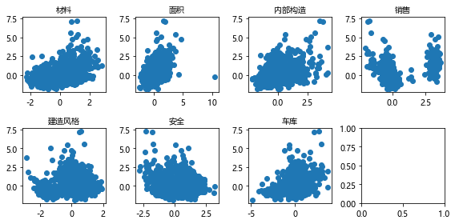

```python
import matplotlib
plt.rcParams['font.sans-serif'] = ['Microsoft YaHei']
#识别中文
matplotlib.rcParams['axes.unicode_minus']=False
fig, axes = plt.subplots(2, 4, figsize=(8,4))
for i in range(7):
    axes[i//4,i%4].scatter(df_fatsc.iloc[:,i],SalePrice)
    axes[i//4,i%4].set_title(df_fatsc.columns.values[i],fontsize=10)
fig.tight_layout()
```

画出散点图，认为自变量和因变量SalePrice之间存在线性趋势，可尝试使用线性模型进行拟合

**异常值检验**

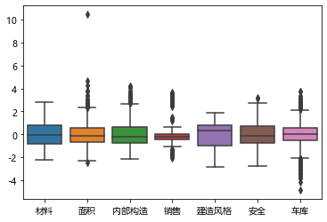

```python
sns.boxplot(data=df_fatsc)
```

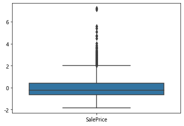

```python
sns.boxplot(data=pd.DataFrame(SalePrice))
```

**对数变换**

考虑到数据集中存在负值，因此将数据加上一个常数后再进行对数变换

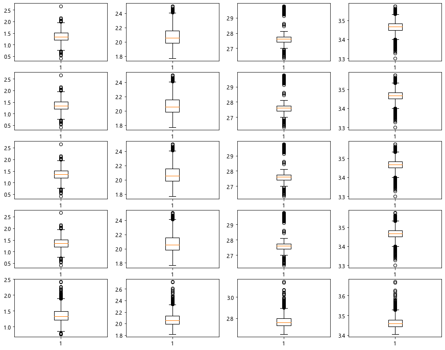

```python
fig, axes = plt.subplots(5, 4, figsize=(15,8))
for i in range(4):
    for j,x in enumerate(["面积",'内部构造','销售','车库']):
        temp = df_fatsc[x]+pow(2,2+j)
        nanlog.append(np.log(temp).isnull().sum())
        axes[i,j].boxplot(list(np.log(temp)))
for i in range(4):
    axes[4,i].boxplot(list(np.log(SalePrice+pow(2,i+1))))
```

**boxcox变换**

```python
from scipy.stats import boxcox
```

```
车库+2^(0+1) is not positive
SalePrice+2^(0+2) is not positive
```

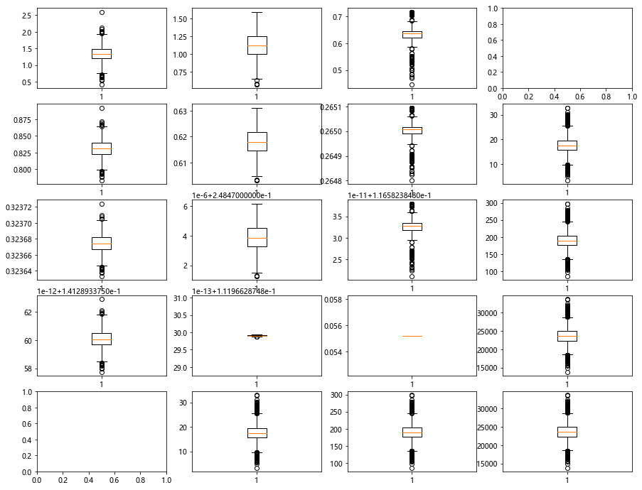

```python
fig, axes = plt.subplots(5, 4, figsize=(15,12))
for i in range(4):
    for j,x in enumerate(["面积",'内部构造','销售','车库']):
        try:
            temp,lamb = boxcox(df_fatsc[x]+pow(2,i+2),lmbda=None,alpha=None)
            axes[i,j].boxplot(list(temp))
        except ValueError:
            print(x+"+2^("+str(i)+"+1) is not positive")
for i in range(4):
    try:
        temp,lamb = boxcox(df_fatsc[x]+pow(2,i+2),lmbda=None,alpha=None)
        axes[4,i].boxplot(list(temp))
    except ValueError:
        print("SalePrice+2^("+str(i)+"+2) is not positive")
```

```python
df_fatsc["内部构造"],lamb = boxcox(df_fatsc["内部构造"]+pow(2,2+2),lmbda=None,alpha=None)
```

**无截距项ols拟合**

```python
ols1 = sm.OLS(SalePrice, df_fatsc).fit()
ols1.summary()
```

OLS Regression Results

| Dep. Variable: | SalePrice | R-squared (uncentered): | 0.590 |
| --- | --- | --- | --- |
| Model: | OLS | Adj. R-squared (uncentered): | 0.588 |
| Method: | Least Squares | F-statistic: | 298.5 |
| Date: | Thu, 06 Jan 2022 | Prob (F-statistic): | 7.42e-276 |
| Time: | 18:06:09 | Log-Likelihood: | -1420.6 |
| No. Observations: | 1460 | AIC: | 2855. |
| Df Residuals: | 1453 | BIC: | 2892. |
| Df Model: | 7 |  |  |
| Covariance Type: | nonrobust |  |  |

|  | coef | std err | t | P>\|t\| | [0.025 | 0.975] |
| --- | --- | --- | --- | --- | --- | --- |
| 材料 | 0.4617 | 0.017 | 27.481 | 0.000 | 0.429 | 0.495 |
| 面积 | 0.4551 | 0.017 | 27.087 | 0.000 | 0.422 | 0.488 |
| 内部构造 | 5.926e-06 | 0.068 | 8.77e-05 | 1.000 | -0.133 | 0.133 |
| 销售 | 0.1619 | 0.017 | 9.636 | 0.000 | 0.129 | 0.195 |
| 建造风格 | 0.2088 | 0.017 | 12.426 | 0.000 | 0.176 | 0.242 |
| 安全 | 0.0005 | 0.017 | 0.028 | 0.978 | -0.032 | 0.033 |
| 车库 | 0.3158 | 0.017 | 18.797 | 0.000 | 0.283 | 0.349 |

| Omnibus: | 693.892 | Durbin-Watson: | 1.993 |
| --- | --- | --- | --- |
| Prob(Omnibus): | 0.000 | Jarque-Bera (JB): | 10144.509 |
| Skew: | 1.833 | Prob(JB): | 0.00 |
| Kurtosis: | 15.382 | Cond. No. | 4.02 |

Notes:  
[1] R² is computed without centering (uncentered) since the model does not contain a constant.  
[2] Standard Errors assume that the covariance matrix of the errors is correctly specified.

可以看到，对公共因子和SalePrice进行最小二乘回归后的R^2为0.590，Ajusted-R^2为0.588，F检验的p值为7.42e-276，模型线性关系显著，拟合效果良好

```python
df_fatsc2 = df_fatsc.drop(['安全','内部构造'],axis=1)
ols2 = sm.OLS(SalePrice, df_fatsc2).fit()
ols2.summary()
```

OLS Regression Results

| Dep. Variable: | SalePrice | R-squared (uncentered): | 0.590 |
| --- | --- | --- | --- |
| Model: | OLS | Adj. R-squared (uncentered): | 0.588 |
| Method: | Least Squares | F-statistic: | 418.5 |
| Date: | Thu, 06 Jan 2022 | Prob (F-statistic): | 1.77e-278 |
| Time: | 18:54:28 | Log-Likelihood: | -1420.6 |
| No. Observations: | 1460 | AIC: | 2851. |
| Df Residuals: | 1455 | BIC: | 2878. |
| Df Model: | 5 |  |  |
| Covariance Type: | nonrobust |  |  |

|  | coef | std err | t | P>\|t\| | [0.025 | 0.975] |
| --- | --- | --- | --- | --- | --- | --- |
| 材料 | 0.4617 | 0.017 | 27.500 | 0.000 | 0.429 | 0.495 |
| 面积 | 0.4551 | 0.017 | 27.106 | 0.000 | 0.422 | 0.488 |
| 销售 | 0.1619 | 0.017 | 9.643 | 0.000 | 0.129 | 0.195 |
| 建造风格 | 0.2088 | 0.017 | 12.435 | 0.000 | 0.176 | 0.242 |
| 车库 | 0.3158 | 0.017 | 18.810 | 0.000 | 0.283 | 0.349 |

| Omnibus: | 693.615 | Durbin-Watson: | 1.993 |
| --- | --- | --- | --- |
| Prob(Omnibus): | 0.000 | Jarque-Bera (JB): | 10136.111 |
| Skew: | 1.833 | Prob(JB): | 0.00 |
| Kurtosis: | 15.377 | Cond. No. | 1.00 |

Notes:  
[1] R² is computed without centering (uncentered) since the model does not contain a constant.  
[2] Standard Errors assume that the covariance matrix of the errors is correctly specified.

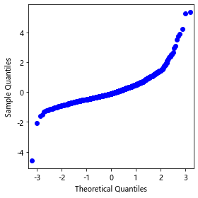

```python
fig, ax = plt.subplots(figsize=(4,4))
smg.qqplot(ols2.resid, ax=ax)
fig.tight_layout()
```

QQ图中残差并非45度斜线，表明残差不服从正态分布

**有截距项ols拟合**

```python
Incp = pd.DataFrame(np.ones(1460),columns=['Intercept'],index=Id)
df_fatsc3 = pd.concat([Incp,df_fatsc],axis=1)
```

```python
ols3 = sm.OLS(SalePrice,df_fatsc3).fit()
ols3.summary()
```

OLS Regression Results

| Dep. Variable: | SalePrice | R-squared: | 0.778 |
| --- | --- | --- | --- |
| Model: | OLS | Adj. R-squared: | 0.777 |
| Method: | Least Squares | F-statistic: | 728.6 |
| Date: | Thu, 06 Jan 2022 | Prob (F-statistic): | 0.00 |
| Time: | 18:53:00 | Log-Likelihood: | -971.11 |
| No. Observations: | 1460 | AIC: | 1958. |
| Df Residuals: | 1452 | BIC: | 2001. |
| Df Model: | 7 |  |  |
| Covariance Type: | nonrobust |  |  |

|  | coef | std err | t | P>\|t\| | [0.025 | 0.975] |
| --- | --- | --- | --- | --- | --- | --- |
| Intercept | -1.28e+05 | 3640.642 | -35.150 | 0.000 | -1.35e+05 | -1.21e+05 |
| 材料 | 0.4629 | 0.012 | 37.473 | 0.000 | 0.439 | 0.487 |
| 面积 | 0.4578 | 0.012 | 37.059 | 0.000 | 0.434 | 0.482 |
| 内部构造 | 5.15e+05 | 1.47e+04 | 35.150 | 0.000 | 4.86e+05 | 5.44e+05 |
| 销售 | 0.1578 | 0.012 | 12.770 | 0.000 | 0.134 | 0.182 |
| 建造风格 | 0.1998 | 0.012 | 16.169 | 0.000 | 0.176 | 0.224 |
| 安全 | -0.0078 | 0.012 | -0.635 | 0.525 | -0.032 | 0.016 |
| 车库 | 0.3206 | 0.012 | 25.947 | 0.000 | 0.296 | 0.345 |

| Omnibus: | 503.451 | Durbin-Watson: | 1.937 |
| --- | --- | --- | --- |
| Prob(Omnibus): | 0.000 | Jarque-Bera (JB): | 49242.453 |
| Skew: | 0.607 | Prob(JB): | 0.00 |
| Kurtosis: | 31.425 | Cond. No. | 1.26e+06 |

Notes:  
[1] Standard Errors assume that the covariance matrix of the errors is correctly specified.  
[2] The condition number is large, 1.26e+06. This might indicate that there are  
strong multicollinearity or other numerical problems.

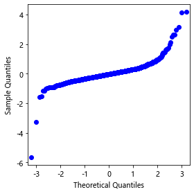

```python
fig, ax = plt.subplots(figsize=(4,4))
smg.qqplot(ols3.resid, ax=ax)
fig.tight_layout()
```

```python
ols4 = sm.OLS(SalePrice, df_fatsc3.drop('安全',axis=1)).fit()
ols4.summary()
```

OLS Regression Results

| Dep. Variable: | SalePrice | R-squared: | 0.778 |
| --- | --- | --- | --- |
| Model: | OLS | Adj. R-squared: | 0.777 |
| Method: | Least Squares | F-statistic: | 850.4 |
| Date: | Thu, 06 Jan 2022 | Prob (F-statistic): | 0.00 |
| Time: | 18:53:23 | Log-Likelihood: | -971.32 |
| No. Observations: | 1460 | AIC: | 1957. |
| Df Residuals: | 1453 | BIC: | 1994. |
| Df Model: | 6 |  |  |
| Covariance Type: | nonrobust |  |  |

|  | coef | std err | t | P>\|t\| | [0.025 | 0.975] |
| --- | --- | --- | --- | --- | --- | --- |
| Intercept | -1.279e+05 | 3639.226 | -35.152 | 0.000 | -1.35e+05 | -1.21e+05 |
| 材料 | 0.4629 | 0.012 | 37.481 | 0.000 | 0.439 | 0.487 |
| 面积 | 0.4578 | 0.012 | 37.066 | 0.000 | 0.434 | 0.482 |
| 内部构造 | 5.148e+05 | 1.46e+04 | 35.152 | 0.000 | 4.86e+05 | 5.44e+05 |
| 销售 | 0.1578 | 0.012 | 12.773 | 0.000 | 0.134 | 0.182 |
| 建造风格 | 0.1998 | 0.012 | 16.172 | 0.000 | 0.176 | 0.224 |
| 车库 | 0.3206 | 0.012 | 25.952 | 0.000 | 0.296 | 0.345 |

| Omnibus: | 509.681 | Durbin-Watson: | 1.936 |
| --- | --- | --- | --- |
| Prob(Omnibus): | 0.000 | Jarque-Bera (JB): | 49310.062 |
| Skew: | 0.634 | Prob(JB): | 0.00 |
| Kurtosis: | 31.442 | Cond. No. | 1.26e+06 |

Notes:  
[1] Standard Errors assume that the covariance matrix of the errors is correctly specified.  
[2] The condition number is large, 1.26e+06. This might indicate that there are  
strong multicollinearity or other numerical problems.

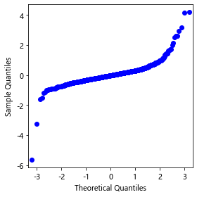

```python
fig, ax = plt.subplots(figsize=(4,4))
smg.qqplot(ols4.resid, ax=ax)
fig.tight_layout()
```

**考虑非线性模型**

```python
inter = []
name = []
faccol = df_fatsc2.columns.values
for i in range(5):
    for j in range(i,5):
        temp = np.multiply(df_fatsc2[faccol[i]],df_fatsc2[faccol[j]])
        name.append(faccol[i]+"*"+faccol[j])
        inter.append(temp)
df_inter = pd.DataFrame(np.array(inter).T,columns=name,index=Id)
df_fain = pd.concat([df_fatsc2,df_inter],axis=1)
```

```python
ols5 = sm.OLS(SalePrice,df_fain).fit()
ols5.summary()
```

OLS Regression Results

| Dep. Variable: | SalePrice | R-squared (uncentered): | 0.656 |
| --- | --- | --- | --- |
| Model: | OLS | Adj. R-squared (uncentered): | 0.652 |
| Method: | Least Squares | F-statistic: | 137.6 |
| Date: | Thu, 06 Jan 2022 | Prob (F-statistic): | 2.99e-316 |
| Time: | 18:54:46 | Log-Likelihood: | -1291.3 |
| No. Observations: | 1460 | AIC: | 2623. |
| Df Residuals: | 1440 | BIC: | 2728. |
| Df Model: | 20 |  |  |
| Covariance Type: | nonrobust |  |  |

|  | coef | std err | t | P>\|t\| | [0.025 | 0.975] |
| --- | --- | --- | --- | --- | --- | --- |
| 材料 | 0.3527 | 0.021 | 16.911 | 0.000 | 0.312 | 0.394 |
| 面积 | 0.4350 | 0.019 | 22.529 | 0.000 | 0.397 | 0.473 |
| 销售 | -0.0826 | 0.052 | -1.589 | 0.112 | -0.185 | 0.019 |
| 建造风格 | 0.0875 | 0.020 | 4.295 | 0.000 | 0.048 | 0.127 |
| 车库 | 0.3064 | 0.018 | 16.861 | 0.000 | 0.271 | 0.342 |
| 材料*材料 | 0.0078 | 0.013 | 0.580 | 0.562 | -0.018 | 0.034 |
| 材料*面积 | 0.0617 | 0.015 | 4.101 | 0.000 | 0.032 | 0.091 |
| 材料*销售 | 0.0593 | 0.031 | 1.917 | 0.055 | -0.001 | 0.120 |
| 材料*建造风格 | -0.0544 | 0.019 | -2.846 | 0.004 | -0.092 | -0.017 |
| 材料*车库 | 0.0962 | 0.019 | 5.018 | 0.000 | 0.059 | 0.134 |
| 面积*面积 | -0.0233 | 0.006 | -3.881 | 0.000 | -0.035 | -0.012 |
| 面积*销售 | -0.0177 | 0.014 | -1.304 | 0.192 | -0.044 | 0.009 |
| 面积*建造风格 | -0.0612 | 0.020 | -3.033 | 0.002 | -0.101 | -0.022 |
| 面积*车库 | 0.0397 | 0.017 | 2.363 | 0.018 | 0.007 | 0.073 |
| 销售*销售 | 0.1061 | 0.017 | 6.260 | 0.000 | 0.073 | 0.139 |
| 销售*建造风格 | -0.0942 | 0.028 | -3.317 | 0.001 | -0.150 | -0.038 |
| 销售*车库 | -0.0101 | 0.019 | -0.547 | 0.585 | -0.046 | 0.026 |
| 建造风格*建造风格 | -0.0771 | 0.015 | -5.087 | 0.000 | -0.107 | -0.047 |
| 建造风格*车库 | 0.0767 | 0.019 | 4.116 | 0.000 | 0.040 | 0.113 |
| 车库*车库 | 0.0216 | 0.009 | 2.427 | 0.015 | 0.004 | 0.039 |

| Omnibus: | 576.771 | Durbin-Watson: | 1.986 |
| --- | --- | --- | --- |
| Prob(Omnibus): | 0.000 | Jarque-Bera (JB): | 3931.559 |
| Skew: | 1.685 | Prob(JB): | 0.00 |
| Kurtosis: | 10.299 | Cond. No. | 14.0 |

Notes:  
[1] R² is computed without centering (uncentered) since the model does not contain a constant.  
[2] Standard Errors assume that the covariance matrix of the errors is correctly specified.

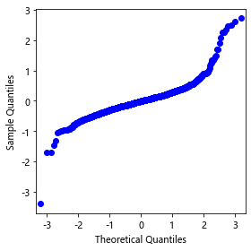

```python
fig, ax = plt.subplots(figsize=(4,4))
smg.qqplot(ols5.resid, ax=ax)
fig.tight_layout()
```

由QQ图可知，残差渐趋正态性，且模型对数据的拟合情况变好，AIC，BIC值也显著减少

```python
df_fain2 = df_fain.drop(["销售",'材料*材料','材料*销售','面积*销售',
                         '面积*建造风格','销售*车库'],axis=1)
```

```python
df_fain2.head()
```

| Id | 材料 | 面积 | 建造风格 | 车库 | 材料*面积 | 材料*建造风格 | 材料*车库 | 面积*面积 | 面积*车库 | 销售*销售 | 销售*建造风格 | 建造风格*建造风格 | 建造风格*车库 | 车库*车库 |
| --- | --- | --- | --- | --- | --- | --- | --- | --- | --- | --- | --- | --- | --- | --- |
| 1 | 0.862319 | -0.602936 | 0.420146 | -0.101357 | -0.519923 | 0.362300 | -0.087402 | 0.363532 | 0.061112 | 0.382525 | -0.259854 | 0.176522 | -0.042585 | 0.010273 |
| 2 | -0.776061 | 0.506280 | 1.200158 | 0.686486 | -0.392904 | -0.931396 | -0.532755 | 0.256320 | 0.347554 | 0.114371 | -0.405879 | 1.440379 | 0.823891 | 0.471263 |
| 3 | 0.887841 | -0.512296 | 0.506429 | 0.071479 | -0.454838 | 0.449628 | 0.063462 | 0.262447 | -0.036618 | 0.400722 | -0.320582 | 0.256470 | 0.036199 | 0.005109 |
| 4 | -0.019304 | -0.176285 | -2.216945 | 0.998997 | 0.003403 | 0.042796 | -0.019285 | 0.031076 | -0.176108 | 0.000356 | 0.041829 | 4.914844 | -2.214721 | 0.997995 |
| 5 | 0.530294 | -0.534032 | 0.385509 | 2.778127 | -0.283194 | 0.204433 | 1.473224 | 0.285190 | -1.483608 | 2.316372 | -0.586730 | 0.148617 | 1.070992 | 7.717988 |

```python
ols6 = sm.OLS(SalePrice,df_fain2).fit()
ols6.summary()
```

OLS Regression Results

| Dep. Variable: | SalePrice | R-squared (uncentered): | 0.653 |
| --- | --- | --- | --- |
| Model: | OLS | Adj. R-squared (uncentered): | 0.649 |
| Method: | Least Squares | F-statistic: | 194.1 |
| Date: | Thu, 06 Jan 2022 | Prob (F-statistic): | 1.33e-319 |
| Time: | 18:57:04 | Log-Likelihood: | -1299.1 |
| No. Observations: | 1460 | AIC: | 2626. |
| Df Residuals: | 1446 | BIC: | 2700. |
| Df Model: | 14 |  |  |
| Covariance Type: | nonrobust |  |  |

|  | coef | std err | t | P>\|t\| | [0.025 | 0.975] |
| --- | --- | --- | --- | --- | --- | --- |
| 材料 | 0.3623 | 0.017 | 21.260 | 0.000 | 0.329 | 0.396 |
| 面积 | 0.4344 | 0.018 | 23.702 | 0.000 | 0.398 | 0.470 |
| 建造风格 | 0.1099 | 0.018 | 6.011 | 0.000 | 0.074 | 0.146 |
| 车库 | 0.3040 | 0.016 | 18.553 | 0.000 | 0.272 | 0.336 |
| 材料*面积 | 0.0619 | 0.015 | 4.135 | 0.000 | 0.033 | 0.091 |
| 材料*建造风格 | -0.0468 | 0.018 | -2.580 | 0.010 | -0.082 | -0.011 |
| 材料*车库 | 0.1008 | 0.018 | 5.539 | 0.000 | 0.065 | 0.136 |
| 面积*面积 | -0.0212 | 0.006 | -3.712 | 0.000 | -0.032 | -0.010 |
| 面积*车库 | 0.0390 | 0.017 | 2.337 | 0.020 | 0.006 | 0.072 |
| 销售*销售 | 0.0946 | 0.006 | 14.621 | 0.000 | 0.082 | 0.107 |
| 销售*建造风格 | -0.0994 | 0.025 | -4.029 | 0.000 | -0.148 | -0.051 |
| 建造风格*建造风格 | -0.0662 | 0.013 | -5.136 | 0.000 | -0.091 | -0.041 |
| 建造风格*车库 | 0.0881 | 0.018 | 4.946 | 0.000 | 0.053 | 0.123 |
| 车库*车库 | 0.0266 | 0.008 | 3.451 | 0.001 | 0.011 | 0.042 |

| Omnibus: | 591.759 | Durbin-Watson: | 1.990 |
| --- | --- | --- | --- |
| Prob(Omnibus): | 0.000 | Jarque-Bera (JB): | 4298.502 |
| Skew: | 1.715 | Prob(JB): | 0.00 |
| Kurtosis: | 10.674 | Cond. No. | 6.05 |

Notes:  
[1] R² is computed without centering (uncentered) since the model does not contain a constant.  
[2] Standard Errors assume that the covariance matrix of the errors is correctly specified.

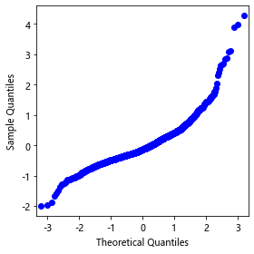

```python
fig, ax = plt.subplots(figsize=(4,4))
smg.qqplot(ols6.resid, ax=ax)
fig.tight_layout()
```

# 总结

画出非线性模型ols6与各变量之间的线性关系

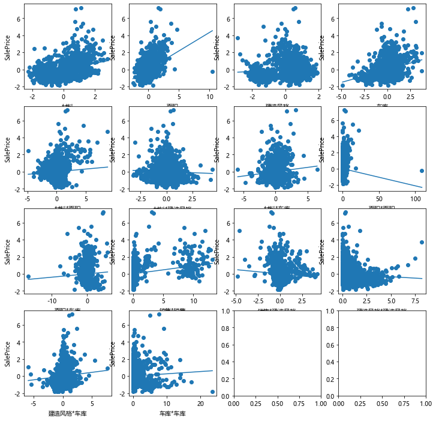

```python
fig, ax = plt.subplots(ncols=4, nrows=4, figsize=(12, 12))
beta = list(ols6.params)
varia = df_fain2.columns.tolist()
k=0
for i in range(4):
    for j in range(4):
        if k==14:break
        m=min(df_fain2.iloc[:,k])
        M=max(df_fain2.iloc[:,k])
        l=np.linspace(m,M,100)
        ll=np.linspace(m*beta[k],M*beta[k],100)
        ax[i,j].plot(l,ll)
        ax[i,j].scatter(df_fain2.iloc[:,k],SalePrice)
        ax[i,j].set_xlabel(varia[k])
        ax[i,j].set_ylabel('SalePrice')
        k+=1
plt.show()
```